# Model Comparison Fit

## Overview

This app shows some basic fitting of data to 2 simple infection models. This shows the concept of model/hypothesis testing. Read about the model in *The Model* tab. Then, work through the tasks described in the *What To Do* tab.

### Learning Objectives

- Understand the idea of model selection and how it relates to hypothesis testing.
- Be familiar with one method for performing model selection.

## The Model

### Model Overview

This app fits 2 different models to virus load data from humans. The idea is that by comparing both models to the data, we can determine which one fits the data better, and, therefore, tentatively suggest that the mechanisms which are part of the better-fitting model might be more realistic descriptions of the underlying biological system.

#### Model 1

This model consists of 4 compartments. The following entities are modeled:

- **U** - uninfected cells
- **I** - infected cells
- **V** - (free) virus
- **X** - T-cells

The following processes/flows are included in the model:

1. Virus infects cells at rate *b*.
2. Infected cells produce new virus at rate *p*, are killed by T-cells at rate *k* and die due to other causes at rate *d<sub>I</sub>*.
3. Free virus is removed at rate *d<sub>V</sub>* or goes on to infect further uninfected cells. It can also infect new cells at rate *b*, with unit conversion factor *g*.
4. T-cells are activated proportional to virus at rate *a* and undergo exponential growth at rate *r*.

#### Model 2

This model also consists of 4 compartments. The following entities are modeled:

- **U** - uninfected cells
- **I** - infected cells
- **V** - (free) virus
- **X** - B-cells/antibodies

The following processes/flows are included in the model:

1. Virus infects cells at rate *b*.
2. Infected cells produce new virus at rate *p* and die at rate *d<sub>I</sub>*.
3. Free virus is removed by antibodies at rate *k*, and by other mechanisms at rate *d<sub>V</sub>*. It can also infect new cells at rate *b*, with unit conversion factor *g*.
4. B-cells/antibodies grow exponentially proportional to virus at rate *a* and decay at rate *d<sub>X</sub>*.

### Model Diagram

The diagram illustrates both compartmental models, with colors to indicate mechanisms that are part of either model 1 or model 2.

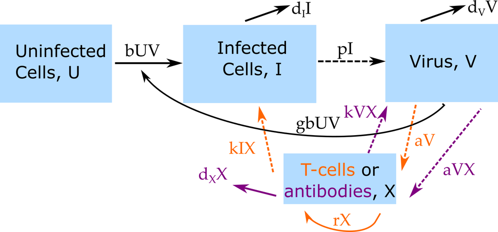

Flow diagram for the 2 models.

### Model Equations

Implementing the models as continuous-time, deterministic systems leads to the following set of ordinary differential equations for model 1:

$$\begin{aligned}
\dot U & = - bUV \\
\dot I & = bUV - d_I I - kIX \\
\dot V & = pI - d_V V - gbUV \\
\dot X & = a V + r X
\end{aligned}$$

Model 2 is described by these equations:
$$\begin{aligned}
\dot U & = - bUV \\
\dot I & = bUV - d_I I \\
\dot V & = pI - d_V V - k V X - gbUV \\
\dot X & = a V X - d_X X
\end{aligned}$$

### Model Concepts

#### Data Source

The data being used in this app comes from (Hayden et al. 1996). Specifically, the data being fit is the ‘no intervention’ viral load data shown in Figure 2 of the paper.

#### Fitting Approach

The basic fitting approach is the one described in the *Basic Virus Model Fitting* app, i.e., we minimize the sum of squares of the log differences between model predictions and virus load data, taking censored values into account.

#### Model Comparison

There are different ways to evaluate how well a model fits to data, and to compare between different models. This app shows the approach of using *Akaike’s “An Information Criterion” (AIC)*, or more precisely, we’ll use the one corrected for small sample size, *AICc*. If we fit by minimizing the sum of squares (SSR), as we do here, the formula for the AICc is:

$$AICc = N \log(\frac{SSR}{N})+2(K+1)+\frac{2(K+1)(K+2)}{N-K}$$

where *N* is the number of data points, *SSR* is the sum of squares residual at the final fit, and *K* is the number of parameters being fit. A lower value for AICc means a better model.

This combination of SSR (or more generally, some measure of *goodness of fit*) with the number of parameters (or more generally, model complexity) tries to find a trade-off between how well a model fits and how big it is. Generally speaking, bigger models fit better. But, this can lead to overfitting. We want to find a good balance between model complexity and fit quality. *AIC* is one way to do that. For AIC, it means a bigger model with lower SSR might still have a higher AIC since model complexity gets penalized. (In our case, since both models have the same number of parameters, the two quantities move in the same direction.)

One nice feature of the AIC is that one can compare as many models as one wants without having issues with p-values or correcting for multiple comparison, and the models do not need to be nested (i.e., each smaller model being contained inside the larger models / a criterion for likelihood ratio tests). That said, AIC has its drawbacks. Nowadays, if one has enough data available, the best approach is to evaluate model performance by a method like cross-validation (Hastie, Tibshirani, and Friedman 2011), and/or if available, building models with one dataset and testing them on a different dataset.

For evaluation of models with different AIC, there is fortunately no arbitrary, magic value (e.g., p=0.05). A rule of thumb is that if models differ by AIC of more than 2, the one with the smaller one is considered statistically better supported (don’t use the word *significant* since that is usually associated with a p-value<0.05, which we don’t have here). I tend to be more conservative and want AIC differences to be at least >10 before I’m willing to favor a given model. Also, I think that visual inspection of the fits is useful. If one model has a lower AIC, but the fit doesn’t look that convincing biologically (e.g., very steep increases or decreases in some quantity), I’d be careful drawing very strong conclusions.

### Notes

- To summarize the models and their differences in words: the main difference between the models are the immune response components.
  - In the first model, T-cells are activated proportional to virus at rate *a*, then grow exponentially at rate *r* and kill infected cells at rate *k*.
  - In the second model, B-cells grow proportional to both virus and B-cells at rate *a*, and die at rate *d<sub>X</sub>*. They remove virus at rate *k*.
- Both models are rather simple and, arguably, somewhat unrealistic.
  - We assume that the T-cells grow exponentially without any limit. This model can be justified if one only tries to fit data from an acute infection (as done here for influenza) where the infection is over (i.e. virus drops below level of detection) before T-cells reach their peak.
  - We assume that the number/amount of antibodies closely follows the number/amount of B-cells and thus we don’t model them separately but instead combine them into a single equation. One could add a separate equation for antibodies, but it won’t change things much in this example (and make the model more complicated).
  - For both models, we ignored birth/death of uninfected cells, which is possibly okay for an acute infection (but needs to be determined based on known biology for a given system).
- In general, models need to be carefully tailored to the question and setting. This is true for models used in fitting even more than for models that are used without trying to perform data fitting. The more data you have available, the more complex a model you can usually justify (as long as you know enough about the system to postulate reasonable hypothetical mechanisms/processes).
- The absolute value of the AIC is unimportant and varies from dataset to dataset. Only relative differences matter. And it goes without saying that we can only compare models that are fit to exactly the same data.

## What to do

**The tasks below are described in a way that assumes everything is in units of days (rate parameters, therefore, have units of inverse days). If any quantity is not given in those units, you need to convert it first (e.g. if it says a week, you need to convert it to 7 days).**

### Task 1

Take a look at the inputs and outputs for the app. It is similar to the previous fitting apps. To keep things simple, the confidece interval computation part is not present. Each model has 3 parameters which are being estimated (*a*, *b* and and *r* for model 1 and *a*, *b* and *dX* for model 2). You might wonder why the other parameters are fixed, especially since in previous examples we fitted parameters such as *p* and *dV*. The only reason here is to keep things simple, and given the small amount of data, it is not possible to estimate more parameters. For a real problem, you would need good outside scientific knowledge to justify fixing some parameters (e.g., those were measured fairly precisely in separate experiments). Otherwise, you would need to fit those parameters, or, if you don’t have enough data (i.e., you might be overfitting), you’ll have to simplify your model.

In this example, the model with the lower AICc also have the lower SSR. Why is that so? Is that always true for any 2 models? (It’s not: The 2 models here are in some sense special, understand how/why.) If you have a hard time figuring this out, I suggest you take the AICc equation and compute it manually for both models by inserting SSR and K (number of parameters) and data points (here N = 8).

**Record**

- AICc for model 2, 500 interation (round to 2 digits).
- TRUE or FALSE: AICc and SSR agree in ranking different models if the models have the same number of parameters.

### Task 2

Based on what we just did and found, we would conclude that model 2 better matches the data, and thus B-cells are more likely to important in this system compared to T-cells. Of course the major caveat is: **Given all other assumptions**. In this case, the assumptions are both how we build the models, and which parameters we assumed to be fixed and the values we gave them. We can’t easily explore different model implementations here, but we can explore how other choices for the fixed model parameters might impact our conclusions. Reset all inputs, then set dI=1, dV=8. We are basically now assuming that infected cells live twice as long (24h instead of 12h) and virus is cleared twice as fast. The choices for fixed parameters need to come from the literature, but there is usually some range of reasonable values. Run a single iteration for model 1, you should find AICc = 18.95. Now run it for 500 iterations. The AICc will have gone down (though is still positive). Then run model 2 for 500 iterations. You’ll find that again, model 2 is better, though not surprisingly, the best fit estimates for the parameters are different than those found in the previous task.

You can increase the number of iterations or the starting values for the parameters. I think (but have not exhaustively tested) that model 2 will continue to be able to produce a better fit compared to model 1. This suggests that model 2 might be robustly better than model 1. However, it could be that there are some settings for the fixed parameters for which model 1 performs better.

**Record**

- AICc for model 1, 500 interations (round to 2 digits).
- AICc for model 2, 500 interations (round to 2 digits).

### Task 3

Keep exploring. For instance change the bounds for the parameters. As you learned, this shouldn’t affect the best fit (as long as the best fit estimate is not at one of the bounds), but you’ll see that it might still do so. In practice, you would need to try multiple solvers with multiple starting values to determine which model is better. You could also explore if the model ranking remains if you change assumptions for your non-fitted parameters. You could for instance systematically vary them over ranges, or sample them - using approaches you saw in previous apps. The amount of exploration you do is some kind of cost-benefit trade-off. You could always do more, but at some point you have to decide it’s enough to satisfy you (and the reviewers and your audience).

The overall point to take away from this app is that while model comparison can be informative and useful, you always need to keep in mind that it relies on other assumptions you made about model type and structure, and choices of fixed parameter values (if you fixed any).

**Record**

- Nothing

## Further Information

- This app (and all others) are structured such that the Shiny part (the graphical interface you see and the server-side function that goes with it) calls an underlying R script (or several) which runs the simulation for the model of interest and returns the results.
- For this app, the underlying function running the simulation is called `simulate_modelcomparison_fit`. You can call them directly, without going through the shiny app. Use the `help()` command for more information on how to use the functions directly. If you go that route, you need to use the results returned from this function and produce useful output (such as a plot) yourself.
- You can also download all simulator functions and modify them for your own purposes. Of course to modify these functions, you’ll need to do some coding.
- For examples on using the simulators directly and how to modify them, read the package vignette by typing `vignette('DSAIRM')` into the R console.

### References

Hastie, Trevor, Robert Tibshirani, and Jerome Friedman. 2011. *The Elements of Statistical Learning: Data Mining, Inference, and Prediction, Second Edition (Springer Series in Statistics)*. Springer.

Hayden, F G, J J Treanor, R F Betts, M Lobo, J D Esinhart, and E K Hussey. 1996. “[Safety and Efficacy of the Neuraminidase Inhibitor GG167 in Experimental Human Influenza.](https://www.ncbi.nlm.nih.gov/pubmed/8544269)” *JAMA* 275 (4): 295–99.